# Project 2: Supervised and Unsupervised Learning

SDS322E

#### Names of Your Group Here

Allison McNairy,Thao Nguyen, Shuhan Shen

### Introduction

Our objective for this project is to investigate the various relationships between variables in the Pima Indians Diabetes Database by performing supervised and unsupervised learning classifications. The dataset we are using is called PimaIndiansDiabetes, which has 768 observations on 9 variables that display various medical statistics for women of Pima Indian heritage. The variables include number of times pregnant, plasma glucose concentration, blood pressure, tricep skin thickness, insulin concentration, BMI, diabetes pedigree function, age, and if the patient has diabetes or not. We converted the categorical variable of does a patient have diabetes or not from “yes” and “no” to binary 1 or 0, respectively. For this variable, 268 of the patients in the dataset have diabetes (1), and 500 do not have diabetes (0). We found our dataset by searching for machine learning R packages within the Machine Learning Mastery website (https://machinelearningmastery.com/machine-learning-datasets-in-r/).

### Libraries and data sources

```r
library(mlbench)
library(tidyverse)
library(dslabs)
library(caret)
library(pROC)
library(rpart.plot)
library(randomForest)
library(dplyr)
library(gridExtra)
library(grid) # required to draw arrows
library(ggthemes) # for colorblind color scale
library(GGally)
library(ggfortify)

data(PimaIndiansDiabetes)
PID <- PimaIndiansDiabetes %>%
  mutate(diabetes_new = factor(ifelse(diabetes == "pos",1,0)))
PID<-PID[,-9]
head(PID)
```

```
##   pregnant glucose pressure triceps insulin mass pedigree age diabetes_new
## 1        6     148       72      35       0 33.6    0.627  50            1
## 2        1      85       66      29       0 26.6    0.351  31            0
## 3        8     183       64       0       0 23.3    0.672  32            1
## 4        1      89       66      23      94 28.1    0.167  21            0
## 5        0     137       40      35     168 43.1    2.288  33            1
## 6        5     116       74       0       0 25.6    0.201  30            0
```

### Common Used Function

Functions are joint crossing multiple parts

#### Statistic Function

The function aim to summary the evaluation parameter of models. Including: accuracy, sensitivity, specificity and AUC

```r
class_diag <- function(score, truth, positive, cutoff=.5){

  pred <- factor(score>cutoff,levels=c("TRUE","FALSE"))
  truth <- factor(truth==positive, levels=c("TRUE","FALSE"))

  tab<-table(truth, pred)
  acc=sum(diag(tab))/sum(tab)
  sens=tab[1,1]/rowSums(tab)[1]
  spec=tab[2,2]/rowSums(tab)[2]
  ppv=tab[1,1]/colSums(tab)[1]

  #CALCULATE EXACT AUC
  truth<-as.numeric(truth=="TRUE")
  ord<-order(score, decreasing=TRUE)
  score <- score[ord]; truth <- truth[ord]
  TPR=cumsum(truth)/max(1,sum(truth))
  FPR=cumsum(!truth)/max(1,sum(!truth))
  dup<-c(score[-1]>=score[-length(score)], FALSE)
  TPR<-c(0,TPR[!dup],1); FPR<-c(0,FPR[!dup],1)
  n <- length(TPR)
  auc<- sum( ((TPR[-1]+TPR[-n])/2) * (FPR[-1]-FPR[-n]) )
  round(data.frame(acc,sens,spec,auc, row.names = "Metrics"),4)
}
```

#### Split train and test data function

```r
train_set<-function(data1, proportion,model){
  idx_train <- sample(1:nrow(data1), floor(proportion * nrow(data1)))
  PID_train <- data1[idx_train,]
  PID_test <- data1[-idx_train,]
  return(model(PID_train,PID_test))
}
```

### Logistic Regression

#### Entire Datasets

```r
set.seed(1000)
## regress on everything
lr_prima_model <- glm(diabetes_new ~ ., family = binomial, data = PID)

## get predictions
lr_predict <- predict(lr_prima_model, PID, type = "response")

# cutoff probability of 0.5
prob_myfit <- ifelse(lr_predict > 0.5, "1", "0")

## get statistics
class_diag(prob_myfit,truth=PID$diabetes_new, positive=1)
```

```
##            acc   sens spec   auc
## Metrics 0.7826 0.5821 0.89 0.736
```

Compute AUC from ROC Curve

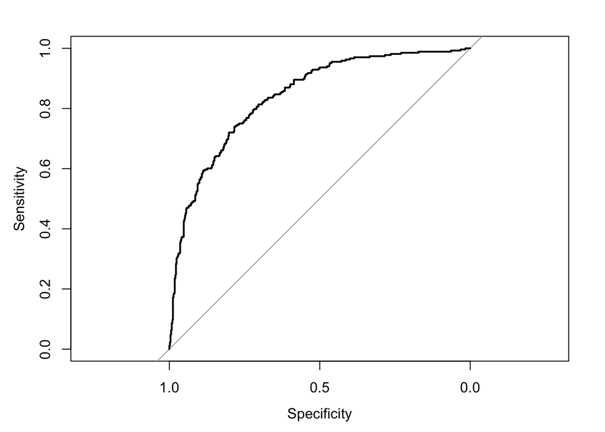

```r
roc_prima <- roc(lr_prima_model$y, lr_predict)
plot(roc_prima)
```

**How well do you feel that your classifier is doing in terms of prediction?**

Answer: The accuracy of the model is only about 78.3%, which appears to be an under performance given that good glm models present an accuracy of over 90%. Since we treat having diabetes has the true positive case, the specificity is 0.89 whereas our sensitivity is 0.582. This means the regression computes many true negatives. The test would most likely perform better if sensitivity also increased. Insulin concentration, triceps thickness, and age are not statistically significant in the model, and may be lowering the accuracy overall. The AUC as 0.736 shows that the model has a moderate to fair discrimination ability.

#### Average for Train/ Testsets

```r
lr_prima_model2 <- function(PID_training,PID_testing){
  PID_lr <- glm(diabetes_new ~ ., family = binomial, data = PID)
  PID_lr_predict <- predict(PID_lr, PID_testing)
  PID_lr_predict<- as.vector(PID_lr_predict)
  Z<-class_diag(PID_lr_predict,truth=PID_testing$diabetes_new, positive=1)
  return(Z)
}
## setting different seeds for each run
set.seed(1000)
lr_1 <-train_set(PID,0.8,lr_prima_model2)

set.seed(5000)
lr_2 <- train_set(PID,0.8,lr_prima_model2)

set.seed(10000)
lr_3 <-train_set(PID,0.8,lr_prima_model2)

set.seed(50000)
lr_4 <-train_set(PID,0.8,lr_prima_model2)

set.seed(70000)
lr_5 <-train_set(PID,0.8,lr_prima_model2)

set.seed(3000)
lr_avg <-train_set(PID,0.8,lr_prima_model2)
#compute the average of all the statistics
for (i in 1:4){
  lr_avg[1,i]<- (lr_1[1,i]+lr_2[1,i]+lr_3[1,i]+lr_4[1,i]+lr_5[1,i])/5
}
lr_avg
```

```
##             acc   sens    spec    auc
## Metrics 0.78702 0.5085 0.94116 0.8511
```

### Tree-based Classifiers

#### Decision Tree Model

Training best parameters Finding best value of CP,best cutoff based on accurary and decision tree model with diagram

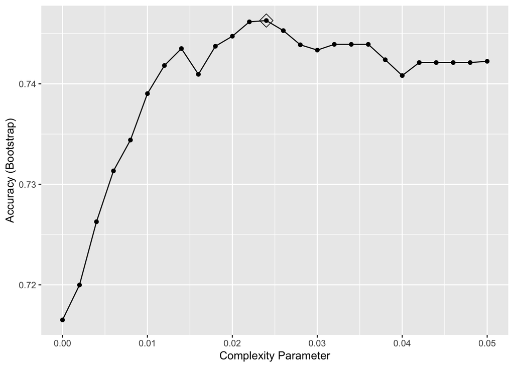

```r
#Finding best value of CP
set.seed(1500)
tune_grid <- data.frame(cp = seq(from = 0, to = 0.05, by = 0.002))
trained_rpart <- train(
  diabetes_new ~ .,
  data = PID,
  method = 'rpart',
  tuneGrid = tune_grid,
  control = rpart.control(minsplit = 20)
)
ggplot(trained_rpart, highlight = TRUE)
```

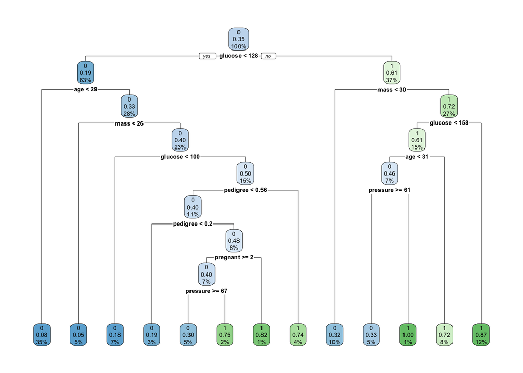

```r
# decision tree model with diagram
PID_dt <- rpart(diabetes_new ~ .,
                 data = PID,
                 control = rpart.control(cp = 0.013))
rpart.plot(PID_dt)
```

```r
#Finding best cutoff based on accurary
accuracy <- numeric(20)
cutoff <- seq(0,1,length.out=20)
for(i in 1:length(cutoff)){
  yhat <-ifelse(predict(PID_dt)[,2]>cutoff[i], 1,0)
  accuracy[i] <- mean(yhat == PID$diabetes_new)
}
accuracy
```

```
##  [1] 0.3489583 0.3971354 0.6901042 0.6901042 0.7526042 0.7526042 0.7734375
##  [8] 0.8281250 0.8281250 0.8281250 0.8281250 0.8281250 0.8281250 0.8281250
## [15] 0.7695312 0.7617188 0.7526042 0.6640625 0.6640625 0.6510417
```

```r
paste("maximun: ",max(accuracy))
```

```
## [1] "maximun:  0.828125"
```

#### Entire Datasets

Result of Decision tree model for entire dataset

```r
p_cut_off <-0.42105263
score <-ifelse(predict(PID_dt)[,2]>p_cut_off, 1,0)

class_diag(score,truth=PID$diabetes_new, positive=1)
```

```
##            acc   sens  spec    auc
## Metrics 0.8281 0.6716 0.912 0.7918
```

#### Average for Train/ Testsets

```r
dt_model <- function(PID_train,PID_test){
  PID_dt_train <- rpart(diabetes_new ~ .,
                data = PID_train,
                control = rpart.control(cp = 0.034))
  predicted <- predict(PID_dt_train, PID_test)
  M<-class_diag(predicted[,2],truth=PID_test$diabetes_new, positive=1)
  return(M)
}
```

Result of Decision tree model for Average Train/Test dataset for 5 seeds

```r
set.seed(1000)
dt_caret_1 <- train_set(PID,0.8,dt_model)
set.seed(5000)
dt_caret_2 <- train_set(PID,0.8,dt_model)
set.seed(10000)
dt_caret_3 <- train_set(PID,0.8,dt_model)
set.seed(50000)
dt_caret_4 <- train_set(PID,0.8,dt_model)
set.seed(70000)
dt_caret_5 <- train_set(PID,0.8,dt_model)
set.seed(3000)
dt_caret_Avg <- train_set(PID,0.8,dt_model)

#finding average
for (i in 1:4){
  dt_caret_Avg[1,i]<- (dt_caret_1[1,i]+dt_caret_2[1,i]+dt_caret_3[1,i]+dt_caret_4[1,i]+dt_caret_5[1,i])/5
}
dt_caret_Avg
```

```
##             acc    sens    spec     auc
## Metrics 0.76234 0.53204 0.89176 0.71392
```

#### Entire Dataset

```r
  set.seed(1500)
  PID_rf <- randomForest(diabetes_new ~., data = PID)
  PID_rf_predict <- predict(PID_rf, PID)
  PID_rf_predict<- as.vector(PID_rf_predict)
  class_diag(PID_rf_predict,truth=PID$diabetes_new, positive=1)
```

```
##         acc sens spec auc
## Metrics   1    1    1   1
```

The RandomForest model accuracy for entire dataset is 1, which is normal because the model is overfitting. In this case we need to using train/test set split to adapt different sets of data

#### Train/Test Set

```r
rf_model <- function(PID_train,PID_test){
  PID_rf <- randomForest(diabetes_new ~., data = PID_train)
  PID_rf_predict <- predict(PID_rf, PID_test)
  PID_rf_predict<- as.vector(PID_rf_predict)
  M<-class_diag(PID_rf_predict,truth=PID_test$diabetes_new, positive=1)
  return(M)
}
```

```r
set.seed(1000)
rf_caret_1 <- train_set(PID,0.8,rf_model)
set.seed(5000)
rf_caret_2 <- train_set(PID,0.8,rf_model)
set.seed(10000)
rf_caret_3 <- train_set(PID,0.8,rf_model)
set.seed(50000)
rf_caret_4 <- train_set(PID,0.8,rf_model)
set.seed(70000)
rf_caret_5 <- train_set(PID,0.8,rf_model)
set.seed(3000)
rf_caret_Avg <- train_set(PID,0.8,rf_model)

#finding average
for (i in 1:4){
  rf_caret_Avg[1,i]<- (rf_caret_1[1,i]+rf_caret_2[1,i]+rf_caret_3[1,i]+rf_caret_4[1,i]+rf_caret_5[1,i])/5
}
rf_caret_Avg
```

```
##             acc    sens    spec    auc
## Metrics 0.77922 0.60268 0.88148 0.7421
```

### Regression/Numeric Prediction

Create a rmse_model function to return the RMSE for a model with the input of the real observation(outcome) and their predicted values (predict_outcome) from a model, RMSE reflects the difference between them.

```r
rmse_model <- function(outcome, predict_outcome) {
  rmse <- sqrt(mean((outcome - predict_outcome)^2))
  return(rmse)
}
```

We are interested in learning the relationship between glucose concentration with blood pressure, triceps, insulin, body mass, etc. and we wanted to know what variable have a bigger weight in affecting the glucose level.

We fit a multiple linear regression with glucose concentration as the dependent variable and all other independent variables except for diabetes_new (reflects whether a Pima Indian has diabetes or not). We wanted to study whether this model works better with or without the diabetes_new.

```r
glucose_lm <- lm(glucose ~. -diabetes_new, data = PID)
print(glucose_lm)
```

```
##
## Call:
## lm(formula = glucose ~ . - diabetes_new, data = PID)
##
## Coefficients:
## (Intercept)     pregnant     pressure      triceps      insulin         mass
##    66.24116      0.05891      0.07003     -0.33425      0.10048      0.75029
##    pedigree          age
##     6.31624      0.64526
```

```r
glucose_predict <- glucose_lm$fitted.values
rmse_model(glucose_predict, PID$glucose)
```

```
## [1] 28.03478
```

The RMSE for this model (without diabetes_new) is 28.035.and pedigree (likelihood of diabetes based on family history) has the biggest coefficient value.

Next, we run a similar model but this time, we include diabetes_new as our independent variable to see if the model works better.

```r
glucose_lm2 <- lm(glucose ~.,data = PID)
print(glucose_lm2)
```

```
##
## Call:
## lm(formula = glucose ~ ., data = PID)
##
## Coefficients:
##   (Intercept)       pregnant       pressure        triceps        insulin
##       77.8019        -0.4654         0.1180        -0.2886         0.0901
##          mass       pedigree            age  diabetes_new1
##        0.3075         1.6934         0.4840        25.0380
```

```r
glucose_predict2 <- glucose_lm2$fitted.values
rmse_model(glucose_predict2, PID$glucose)
```

```
## [1] 25.87366
```

The RMSE for this model is 25.874, which is smaller than the previous model. Since this model works better and diabetes_new is a good variable to predict glucose concentration, we should include it in the model. Some coefficients change the sign and diabetes_new becomes the variable with the highest weight on changes for glucose predictions.

Use caret to perform k-fold cross-validation on the same model with k=5.

```r
set.seed(12345)
control <- trainControl(method = "cv", number = 5)

cv_lm <- train(glucose ~., data = PID, trControl = control, method = 'lm')
print(cv_lm)
```

```
## Linear Regression
##
## 768 samples
##   8 predictor
##
## No pre-processing
## Resampling: Cross-Validated (5 fold)
## Summary of sample sizes: 615, 614, 615, 613, 615
## Resampling results:
##
##   RMSE      Rsquared   MAE
##   26.38667  0.3244028  20.15173
##
## Tuning parameter 'intercept' was held constant at a value of TRUE
```

Cross-validation with 5 folds was used, and the sample size for each training set is between 613 and 615. The average RMSE is 26.387, which is slightly higher than our previous model.

Return the final model fit and view the model predictions (RMSE, Rsquared, MAE) for each of the 5 folds.

```r
cv_lm$finalModel
```

```
##
## Call:
## lm(formula = .outcome ~ ., data = dat)
##
## Coefficients:
##   (Intercept)       pregnant       pressure        triceps        insulin
##       77.8019        -0.4654         0.1180        -0.2886         0.0901
##          mass       pedigree            age  diabetes_new1
##        0.3075         1.6934         0.4840        25.0380
```

```r
cv_lm$resample
```

```
##       RMSE  Rsquared      MAE Resample
## 1 24.67420 0.3289441 19.35496    Fold1
## 2 29.86846 0.2926240 22.31305    Fold2
## 3 26.23248 0.2769035 20.25482    Fold3
## 4 25.78323 0.4124535 20.42443    Fold4
## 5 25.37500 0.3110888 18.41137    Fold5
```

The RMSE accross 5 folds are: 24.674, 29.868, 26.232, 25.783 and 25.375.

Create glucose train and test sets with 80% train and 20% test.

```r
idx <- createDataPartition(PID$glucose, p = 0.8)[[1]]
glucose_train <- PID[idx,]
glucose_test <- PID[-idx,]
```

Create a random forest similar to glucose_lm2 with glucose as the response variable and all other indicators as independent variables.

```r
glucose_rf <- randomForest(glucose ~., data = glucose_train)
glucose_rf_predict <- predict(glucose_rf, glucose_test, type="class")
rmse_model(glucose_rf_predict, PID$glucose)
```

```
## [1] 36.81573
```

```r
set.seed(123456)
control <- trainControl(method = "cv", number = 5)
cv_lm_rf <- train(glucose ~., data = PID, trControl = control, method = 'rf')
print(cv_lm_rf)
```

```
## Random Forest
##
## 768 samples
##   8 predictor
##
## No pre-processing
## Resampling: Cross-Validated (5 fold)
## Summary of sample sizes: 615, 615, 615, 614, 613
## Resampling results across tuning parameters:
##
##   mtry  RMSE      Rsquared   MAE
##   2     26.21104  0.3340340  19.87524
##   5     26.63275  0.3161630  20.23666
##   8     26.89676  0.3063598  20.45319
##
## RMSE was used to select the optimal model using the smallest value.
## The final value used for the model was mtry = 2.
```

```r
cv_lm_rf$finalModel
```

```
##
## Call:
##  randomForest(x = x, y = y, mtry = param$mtry)
##                Type of random forest: regression
##                      Number of trees: 500
## No. of variables tried at each split: 2
##
##           Mean of squared residuals: 692.5376
##                     % Var explained: 32.17
```

```r
cv_lm_rf$resample
```

```
##       RMSE  Rsquared      MAE Resample
## 1 31.59158 0.2234927 21.94413    Fold1
## 2 24.11077 0.3719818 19.34292    Fold2
## 3 26.22526 0.2615002 20.13375    Fold5
## 4 25.08503 0.3765404 19.85509    Fold4
## 5 24.04257 0.4366548 18.10030    Fold3
```

The RMSE across 5 folds are: 31.592, 24.111, 26.225, 25.085 and 24.043.

**How does the results from k-fold cross-validation between the two methods compare? Which method seems to perform best?**

Answer: Focusing on the most optimal model (mtry=2) of the cv_lm_rf model, we found that the RMSE of a random forest with k-fold cross-validation method to be 26.211, much smaller than the RMSE we draw out of the random forest model itself. This means the k-fold cross-validation performed well in decreasing our RMSE. Besides,this RMSE is also almost equal to the RMSE from the k-fold cross-validation method of the linear model (26.387). Besides the smaller RMSE, the random forest model also has slightly higher Rsquared (0.334, compared to 0.324). However, in my opinion, this difference is not significant so I believe both methods deliver equal performance.

### Unsupervised Learning

```r
data(PimaIndiansDiabetes)
uns_PID <- PimaIndiansDiabetes
```

```r
pca <-uns_PID %>% select(-diabetes) %>% scale() %>% prcomp()
print(pca)
```

```
## Standard deviations (1, .., p=8):
## [1] 1.4471973 1.3157546 1.0147068 0.9356971 0.8731234 0.8262133 0.6479322
## [8] 0.6359733
##
## Rotation (n x k) = (8 x 8):
##                 PC1        PC2         PC3         PC4        PC5          PC6
## pregnant -0.1284321  0.5937858 -0.01308692  0.08069115 -0.4756057  0.193598168
## glucose  -0.3930826  0.1740291  0.46792282 -0.40432871  0.4663280  0.094161756
## pressure -0.3600026  0.1838921 -0.53549442  0.05598649  0.3279531 -0.634115895
## triceps  -0.4398243 -0.3319653 -0.23767380  0.03797608 -0.4878621  0.009589438
## insulin  -0.4350262 -0.2507811  0.33670893 -0.34994376 -0.3469348 -0.270650609
## mass     -0.4519413 -0.1009598 -0.36186463  0.05364595  0.2532038  0.685372179
## pedigree -0.2706114 -0.1220690  0.43318905  0.83368010  0.1198105 -0.085784088
## age      -0.1980271  0.6205885  0.07524755  0.07120060 -0.1092900 -0.033357170
##                  PC7          PC8
## pregnant  0.58879003  0.117840984
## glucose   0.06015291  0.450355256
## pressure  0.19211793 -0.011295538
## triceps  -0.28221253  0.566283799
## insulin   0.13200992 -0.548621381
## mass      0.03536644 -0.341517637
## pedigree  0.08609107 -0.008258731
## age      -0.71208542 -0.211661979
```

```r
pca$scale
```

```
##    pregnant     glucose    pressure     triceps     insulin        mass
##   3.3695781  31.9726182  19.3558072  15.9522176 115.2440024   7.8841603
##    pedigree         age
##   0.3313286  11.7602315
```

Based on the PCA rotation, triceps thickness, insulin concentration, and BMI appear to contribute the most to PC1. However, pregnancy and age appear to contribute the most to PC2.

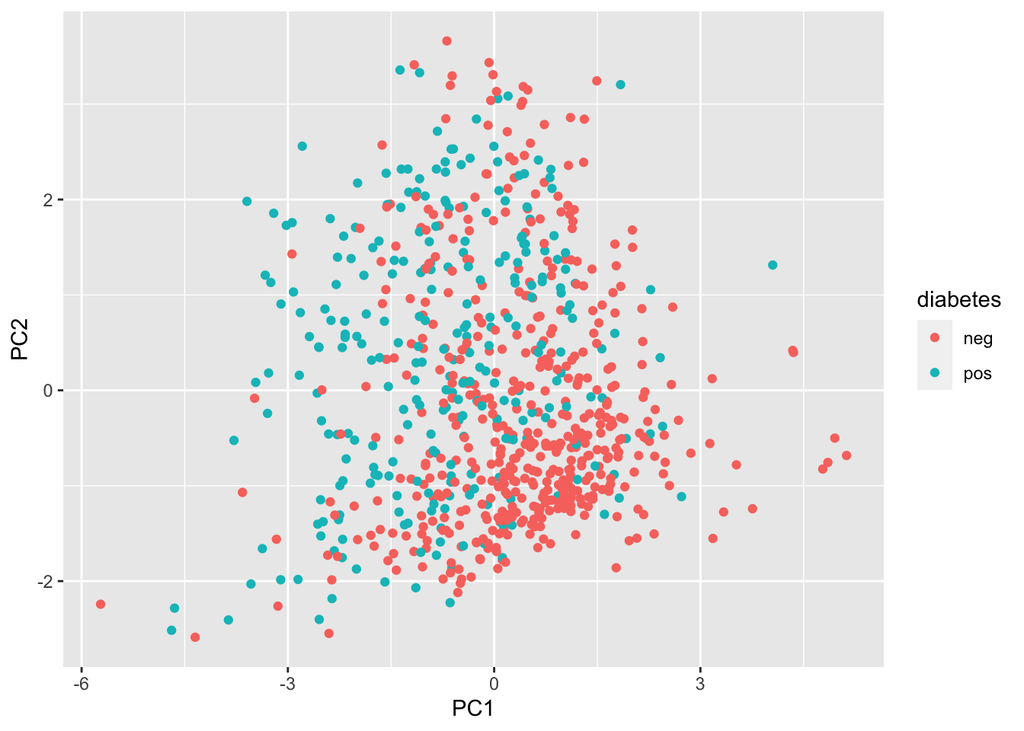

```r
p <- nrow(pca$rotation)
pca_df <- data.frame(pca$x, diabetes = uns_PID$diabetes)
ggplot(pca_df, aes(x = PC1, y = PC2, color = diabetes)) + geom_point()
```

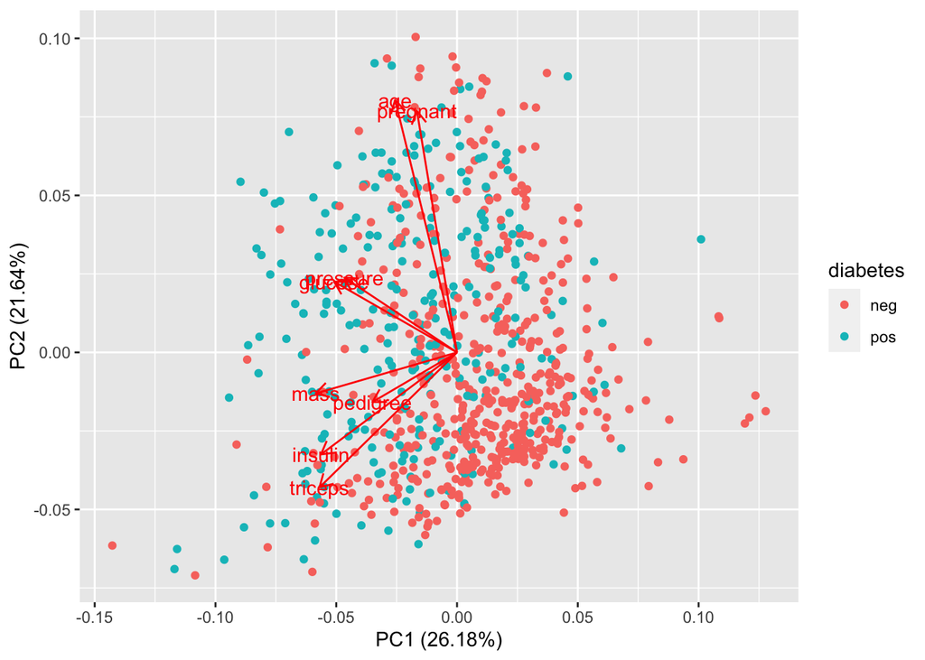

```r
autoplot(
  pca,
  data = uns_PID,
  loadings.label = TRUE,
  loadings = TRUE,
  colour = "diabetes"
)
```

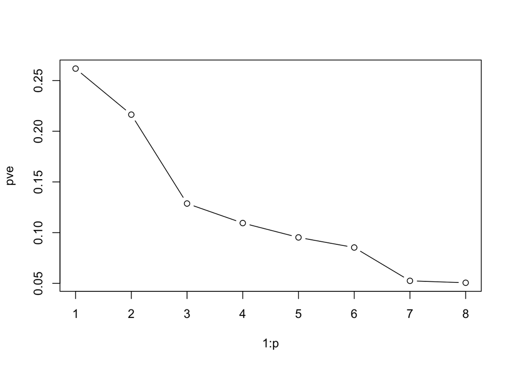

```r
pve <- pca$sdev^2 / sum(pca$sdev^2)
plot(1:p,pve,type="b")
```

```r
pve %>% cumsum()
```

```
## [1] 0.2617975 0.4781988 0.6069025 0.7163436 0.8116367 0.8969652 0.9494422
## [8] 1.0000000
```

```r
sum(pca$sdev^2)
```

```
## [1] 8
```

**how much of the total variance in your dataset is accounted for by the PCs you decide to retain. Do the PCs capture most of the variance in the data?** Answer: Based on the PCA rotation, triceps thickness, insulin concentration, and BMI appear to contribute the most to PC1. However, pregnancy and age appear to contribute the most to PC2. We calculated the proportion of variance accounted for by each PC and determined that about 47.8% of the variance in our data can be attributed to the first two principle components. The PCs only capture half of the variance in our entire dataset.

### Concluding Remarks

###Acknowledgement: Each member within our group contributed equally to the project. Shuhan created common used function and worked on the Tree-based classifier. Allison wrote the introduction and perform the logistic regression analysis. Thao was in charged of the regression/numeric prediction part and worked on the unsupervised learning part with Shuhan. Each member helped organize the direction of our project and finding data sources.